# Take-Home Exercise 2

### 3) Raincloud Plots on Joviality across Educational Levels

**Clarity**:

(+) It is helpful to provide definition of the data (*Joviality*) and plot title for users to better understand the purpose of the chart.

(-) However, without drawing any observations, we are not able to truly appreciate the author’s purpose of the chart. We can only infer from purpose of [raincloud plot](https://towardsdatascience.com/making-it-rain-with-raincloud-plots-496c39a2756f) which is to visualize raw data, the distribution of the data, and key summary statistics at the same time.

**Aesthetics**:

(+) The plots are stacked for easy comparison.

(-) The education level could be rearranged from lowest to highest level for easier readability and comparison.

**Changes**:

Other than addressing the (-) above, the following changes were also made:

1. swap the orientation by removing *coord_flip()* so that we can increase the figure size
2. *fill* argument to color differentiate among education level
3. the rain and the cloud are plotted with some justification to place them next to each other and make room for the box plot.
4. jittered points are included to enhance the data distribution
5. jitterred points are also placed on top of the box plot to reduce cluttering since we already have 4 groups (of education level)
6. include a subtitle to record key observations of the chart

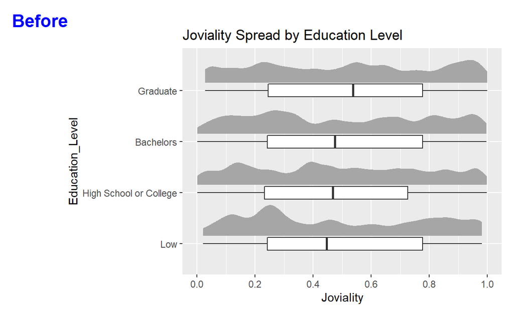

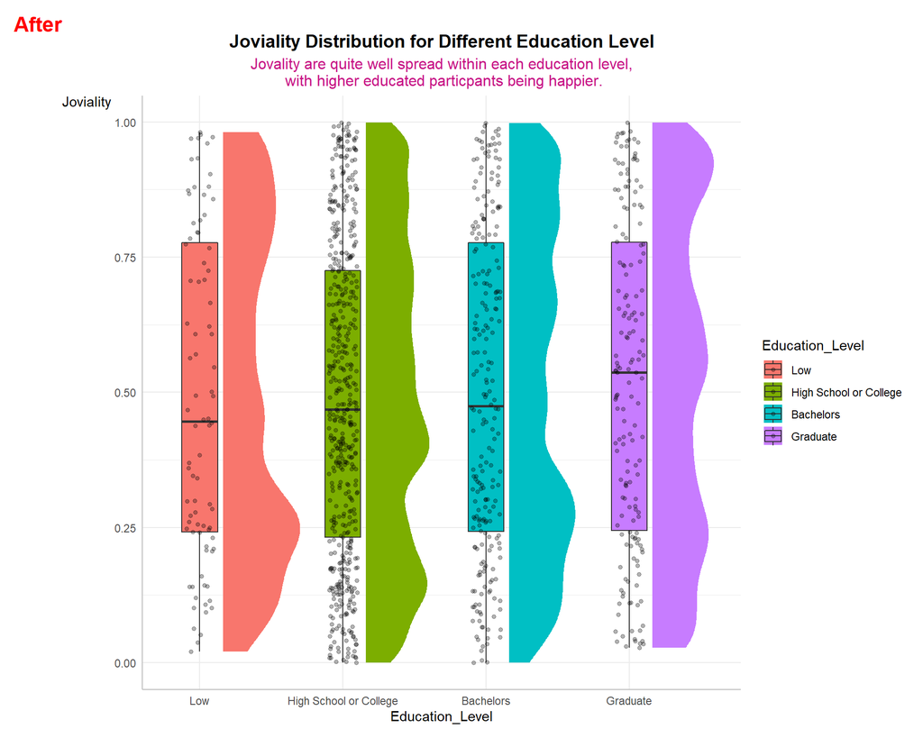

```r
p4b <- ggplot(demographic_data, aes(x = Education_Level, y = Joviality, fill=Education_Level)) +
  ggdist::stat_halfeye(
    adjust = .5,
    width = .6,
    .width = 0,
    justification = -.3,
    point_colour = NA) +
  geom_boxplot(
    width = .25,
    outlier.shape = NA
  ) +
  geom_point(
    size = 1.3,
    alpha = .3,
    position = position_jitter(
      seed = 1, width = .1
    )
  ) +
  coord_cartesian(xlim = c(1.2, NA), clip = "off")+
  ggtitle(label = "Joviality Distribution for Different Education Level",
          subtitle = "Jovality are quite well spread within each education level,\n with higher educated particpants being happier.")+
  theme_minimal()+
  theme(plot.title = element_text(size=14, face="bold",hjust = 0.5),
          plot.subtitle = element_text(size=12,hjust = 0.5,color='mediumvioletred'))+
  theme(axis.title.y= element_text(angle=0), axis.ticks.x= element_blank(),
        panel.background= element_blank(), axis.line= element_line(color= 'grey'))
```

### 4) Ridge Plots on Joviality across Interest Groups

**Clarity**:

(+) It is helpful to include plot title for users to better understand the purpose of the chart.

(-) [Ridgeline plots](https://cran.r-project.org/web/packages/ggridges/vignettes/introduction.html#:~:text=Ridgeline%20plots%20are%20partially%20overlapping,distributions%20over%20time%20or%20space.) are usually meant for visualizing changes in distributions over time or space, which is not the case for this dataset. Without providing any further explanation or summary of the chart we are not able to truly appreciate the author’s purpose of the chart.

**Aesthetics**:

(+) The plots are clean.

(-) The plots does not highlight any key information to communication the author’s intent.

**Changes**:

We suppose that the author would like to see the distribution of joviality across interest groups, as such we continue to use Raincloud plot instead of a Ridge plot. Other than addressing the above (-), the following changes were also made:

1. change the orientation using *coord_flip()* so that it is visiually easier to compare the median of different interest groups
2. *fill* argument to color differentiate among different interest group
3. the box plot are removed to reduce cluttering given that we have 10 interest groups.
4. include a subtitle to record key observations of the chart

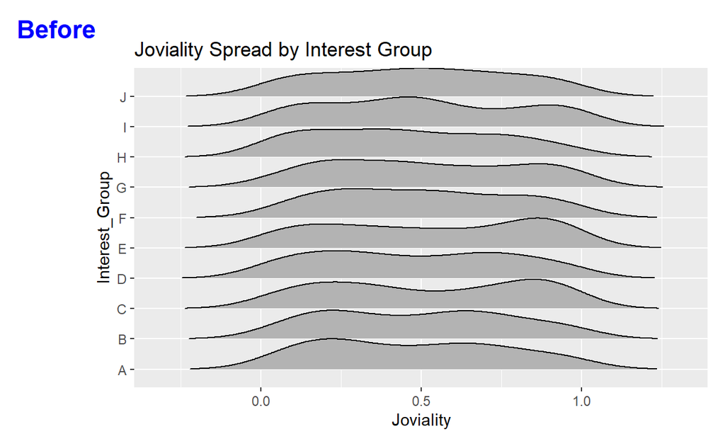

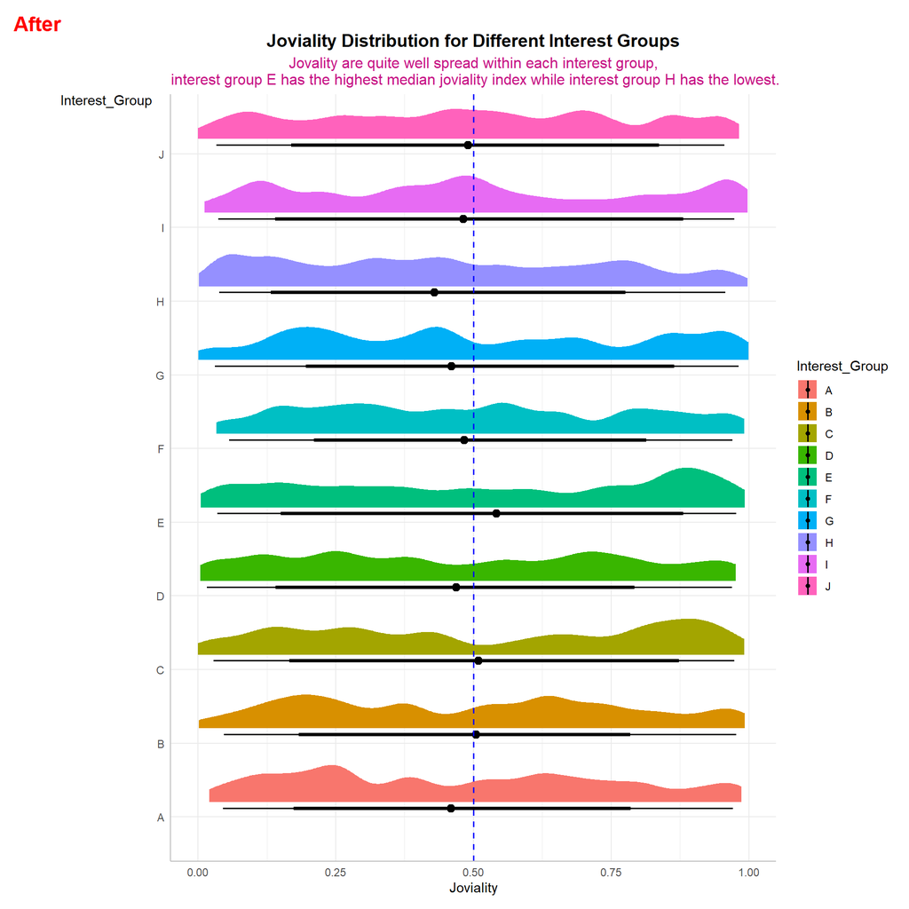

```r
p5b <- ggplot(demographic_data, aes(x = Interest_Group, y = Joviality, fill=Interest_Group)) +
  stat_halfeye(adjust = .35,
               width = .6,
               color = 'black',
               justification = -.15,
               position = position_nudge(x = .12)) +
  geom_hline(aes(yintercept = 0.5),
             linetype= 'dashed',
             color= 'blue',
             size= .6) +
  coord_flip() +
  ggtitle(label = "Joviality Distribution for Different Interest Groups",
          subtitle = "Jovality are quite well spread within each interest group,\n interest group E has the highest median joviality index while interest group H has the lowest.")+
  theme_minimal()+
  theme(plot.title = element_text(size=14, face="bold",hjust = 0.5),
          plot.subtitle = element_text(size=12,hjust = 0.5,color='mediumvioletred'))+
  theme(axis.title.y= element_text(angle=0), axis.ticks.x= element_blank(),
        panel.background= element_blank(), axis.line= element_line(color= 'grey'))
```